# **Reliance Stock Price Analysis**

# **Data Understanding**

```python
df.info()
```

```
<class 'pandas.core.frame.DataFrame'>
DatetimeIndex: 861 entries, 2022-01-03 to 2025-08-08
Data columns (total 8 columns):
 #   Column                 Non-Null Count  Dtype
---  ------                 --------------  -----
 0   (Open, RELIANCE.NS)    861 non-null    float64
 1   (Close, RELIANCE.NS)   861 non-null    float64
 2   (High, RELIANCE.NS)    861 non-null    float64
 3   (Low, RELIANCE.NS)     861 non-null    float64
 4   (Volume, RELIANCE.NS)  861 non-null    int64
 5   (nifty_Close, ^NSEI)   861 non-null    float64
 6   (oil_Close, BZ=F)      861 non-null    float64
 7   (usdinr_Close, INR=X)  861 non-null    float64
dtypes: float64(7), int64(1)
memory usage: 60.5 KB
```

```python
# drop NaN values
df_features = df.dropna().copy()
df_features.reset_index(inplace=True)
df_features.head()
```

| Price Ticker | Date | Open RELIANCE.NS | Close RELIANCE.NS | High RELIANCE.NS | Low RELIANCE.NS | Volume RELIANCE.NS | nifty_Close ^NSEI | oil_Close BZ=F | usdinr_Close INR=X |
| --- | --- | --- | --- | --- | --- | --- | --- | --- | --- |
| 0 | 2022-01-03 | 1080.401299 | 1098.149048 | 1100.022110 | 1079.738882 | 5421611 | 17625.699219 | 78.980003 | 74.513802 |
| 1 | 2022-01-04 | 1103.654004 | 1122.932129 | 1124.256963 | 1098.217641 | 10847728 | 17805.250000 | 80.000000 | 74.403297 |
| 2 | 2022-01-05 | 1124.713718 | 1128.185547 | 1131.566145 | 1111.442782 | 11643813 | 17925.250000 | 80.800003 | 74.534897 |
| 3 | 2022-01-06 | 1119.780073 | 1103.928101 | 1121.059231 | 1100.501826 | 14447422 | 17745.900391 | 81.989998 | 74.430099 |
| 4 | 2022-01-07 | 1110.529323 | 1112.836304 | 1122.909345 | 1101.666806 | 13112115 | 17812.699219 | 81.750000 | 74.419296 |

```python
# daily returns
df_features['reliance_returns'] = df_features['Close'].pct_change()
df_features['nifty_returns'] = df_features['nifty_Close'].pct_change()
df_features['oil_returns'] = df_features['oil_Close'].pct_change()
df_features['usdinr_returns'] = df_features['usdinr_Close'].pct_change()
```

```python
import plotly.io as pio_features
fig_returns = make_subplots(rows=2,cols=2)

fig_returns.add_trace(go.Scatter(x = df.index,
                                     y = df_features['reliance_returns'],
                                     name = 'Reliance Returns',
                                     line = dict(color = 'blue',width = 2)),
                                     row = 1,col= 1)
fig_returns.add_trace(go.Scatter(x = df.index,
                                     y = df_features['nifty_returns'],
                                     name = 'Nifty Returns',
                                     line = dict(color = 'orange',width = 2)),
                                     row = 1,col= 2)
fig_returns.add_trace(go.Scatter(x = df.index,
                                     y = df_features['oil_returns'],
                                     name = 'Oil Returns',
                                     line = dict(color = 'purple',width = 2)),
                                     row = 2,col= 1)
fig_returns.add_trace(go.Scatter(x = df.index,
                                     y = df_features['usdinr_returns'],
                                     name = 'USD/INR Returns',
                                     line = dict(color = 'red',width = 2)),
                                     row = 2,col= 2)

fig_returns.update_layout(
    title = 'Daily Returns Of Reliance, Nifty, Oil and USD/INR',
    height = 700,
    width = 1100,
    legend = dict(
        orientation = 'h',
        yanchor = 'bottom',
        y = 1.02,
        xanchor = 'center',
        x =0.5
    )
)
fig_returns.show()
```

[interactive chart not shown]

**Reliance Returns**

Returns fluctuate mostly between -5% and +5% daily, with occasional spikes beyond ±7%.

**NIFTY Returns**

Returns range around -3% to +3%, showing lower volatility compared to Reliance.

Occasional downward spikes suggest broad market corrections.

**Brent Oil Returns**

Wider fluctuations, frequently reaching ±5% and occasionally beyond ±10%.

Indicates higher volatility, reflecting global supply-demand and geopolitical factors impacting oil prices.

**USD/INR Returns**

Returns are tightly clustered within ±1%, with rare spikes reaching ±2%.

Shows low volatility, consistent with currency markets under RBI’s managed float.

# **Exploratory Data Analysis**

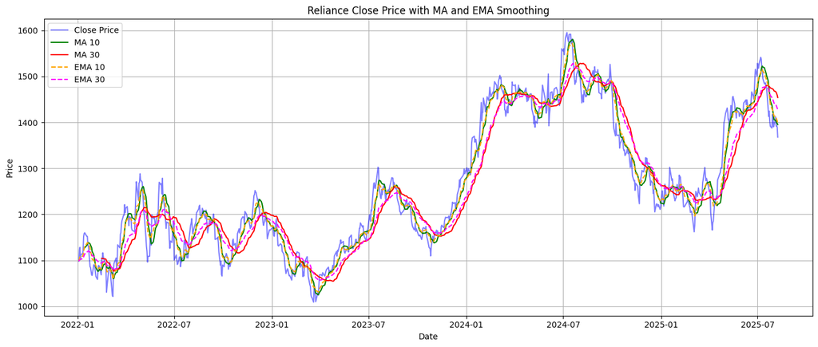

```python
import matplotlib.pyplot as plt

# Compute moving averages
df_features['MA_10'] = df_features['Close'].rolling(window=10).mean()
df_features['MA_30'] = df_features['Close'].rolling(window=30).mean()

# Compute exponential moving averages
df_features['EMA_10'] = df_features['Close'].ewm(span=10, adjust=False).mean()
df_features['EMA_30'] = df_features['Close'].ewm(span=30, adjust=False).mean()

# Plot
plt.figure(figsize=(14,6))
plt.plot(df_features['Date'], df_features['Close'], label='Close Price', color='blue', alpha=0.5)
plt.plot(df_features['Date'], df_features['MA_10'], label='MA 10', color='green')
plt.plot(df_features['Date'], df_features['MA_30'], label='MA 30', color='red')
plt.plot(df_features['Date'], df_features['EMA_10'], label='EMA 10', color='orange', linestyle='--')
plt.plot(df_features['Date'], df_features['EMA_30'], label='EMA 30', color='magenta', linestyle='--')

plt.title('Reliance Close Price with MA and EMA Smoothing')
plt.xlabel('Date')
plt.ylabel('Price')
plt.legend()
plt.grid(True)
plt.tight_layout()
plt.show()
```

Strong upward trend from mid-2023 to mid-2024 is clearly visible across all MAs and EMAs.

EMA lines respond faster to price changes than simple MA, crossing above or below the price line sooner, which can be useful for entry/exit signals.

```python
# Drop NaN values
df_feature= df_features['reliance_returns'].dropna()
```

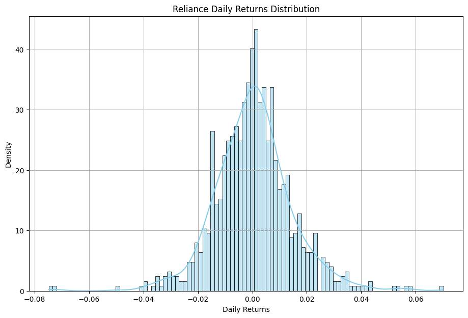

```
Mean Daily Return: 0.00036
Standard Deviation: 0.01431
Skewness: 0.11446
Kurtosis: 3.04712
```

```python
plt.figure(figsize=(11,7))
sns.histplot(df_feature, bins=100, kde=True, color='skyblue', stat='density')
plt.title('Reliance Daily Returns Distribution')
plt.xlabel('Daily Returns')
plt.ylabel('Density')
plt.grid(True)
plt.show()

# Calculate statistics
mean_return = df_feature.mean()
std_return = df_feature.std()
skewness = df_feature.skew()
kurtosis = df_feature.kurtosis()

# Display results
print(f"Mean Daily Return: {mean_return:.5f}")
print(f"Standard Deviation: {std_return:.5f}")
print(f"Skewness: {skewness:.5f}")
print(f"Kurtosis: {kurtosis:.5f}")
```

The histogram with KDE overlay shows the distribution of Reliance’s daily returns over 3+ years:

The distribution is centered near zero, reflecting mean-reverting behavior typical of stock returns.

The shape closely resembles a normal distribution but with slightly heavier tails, indicating occasional extreme returns.

Slight right skewness is visible, with a longer right tail suggesting rare higher positive returns.

# Rolling Volatility Analysis

Calculated as the standard deviation of daily returns over a rolling window (here, 30 days). Helps track how volatility changes over time, revealing periods of market stress or calm. Important for risk-adjusted decision-making and preparing for drawdowns.

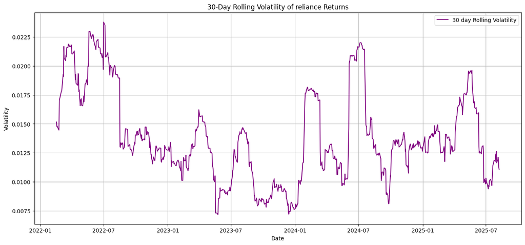

```python
df_features['Volatility'] = df_features['reliance_returns'].rolling(window=30).std()

plt.figure(figsize=(16,7))
plt.plot(df_features['Date'], df_features['Volatility'],label = '30 day Rolling Volatility', color = 'purple')
plt.title('30-Day Rolling Volatility of reliance Returns')
plt.xlabel('Date')
plt.ylabel('Volatility')
plt.legend()
plt.grid(True)
plt.show()
```

The 30-day rolling volatility plot reveals that Reliance’s risk profile changes over time, with periods of calm and spikes in volatility clustering together

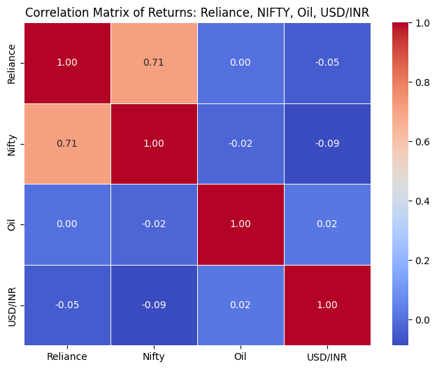

```python
correlation_df = pd.DataFrame({
    'Reliance': df_features['reliance_returns'],
    'Nifty': df_features['nifty_returns'],
    'Oil': df_features['oil_returns'],
    'USD/INR': df_features['usdinr_returns']
})

correlation_df = correlation_df.dropna()
corr_matrix = correlation_df.corr()

plt.figure(figsize=(8, 6))
sns.heatmap(corr_matrix, annot=True, cmap='coolwarm', fmt=".2f", linewidths=0.5)
plt.title('Correlation Matrix of Returns: Reliance, NIFTY, Oil, USD/INR')
plt.show()
```

.Reliance is highly influenced by NIFTY trends, which is expected.

.Despite being in the energy sector, Reliance returns are not significantly correlated with Oil — this highlights its diversification.

.Currency exchange rate (USD/INR) doesn’t have a measurable direct impact on Reliance or NIFTY in this period.

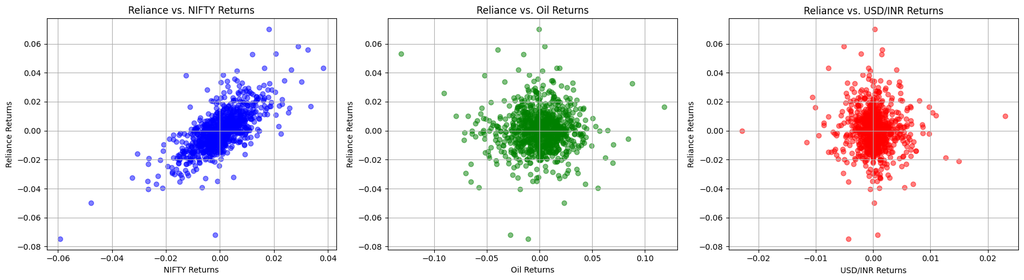

```python
plt.figure(figsize=(18, 5))


plt.subplot(1, 3, 1)
plt.scatter(correlation_df['Nifty'], correlation_df['Reliance'], alpha=0.5, color='blue')
plt.title('Reliance vs. NIFTY Returns')
plt.xlabel('NIFTY Returns')
plt.ylabel('Reliance Returns')
plt.grid(True)

#  Reliance vs. Oil
plt.subplot(1, 3, 2)
plt.scatter(correlation_df['Oil'], correlation_df['Reliance'], alpha=0.5, color='green')
plt.title('Reliance vs. Oil Returns')
plt.xlabel('Oil Returns')
plt.ylabel('Reliance Returns')
plt.grid(True)

# Reliance vs. USD/INR
plt.subplot(1, 3, 3)
plt.scatter(correlation_df['USD/INR'], correlation_df['Reliance'], alpha=0.5, color='red')
plt.title('Reliance vs. USD/INR Returns')
plt.xlabel('USD/INR Returns')
plt.ylabel('Reliance Returns')
plt.grid(True)

plt.tight_layout()
plt.show()
```

# Stationarity Testing and Transformation

**Why Stationarity Matters:**

Non-stationary data can lead to spurious results in time series forecasting.

Most models assume stationarity for valid predictions.

Financial prices are usually non-stationary, while returns are typically stationary.

```python
result_price = adfuller(df_features['Close'].dropna())
print(f"ADF Statistic (Close Price): {result_price[0]}")
print(f"p-value (Close Price): {result_price[1]}")

result_returns = adfuller(df_features['reliance_returns'].dropna())
print(f"ADF Statistic (Returns): {result_returns[0]}")
print(f"p-value (Returns): {result_returns[1]}")
```

```
ADF Statistic (Close Price): -1.9572567402236867
p-value (Close Price): 0.3056230752204351
ADF Statistic (Returns): -28.7877762324863
p-value (Returns): 0.0
```

The null hypothesis (non-stationarity) is not rejected. Reliance closing prices are non-stationary.

Reliance Returns

The null hypothesis is rejected. Reliance returns are stationary.

```python
# log Transformation
df_features['log_close'] = np.log(df_features['Close'])

# Calculate log difference
df_features['log_close_diff'] = df_features['log_close'].diff()
```

```python
# drop NaN Values
df_features.dropna(inplace=True)
```

```python
# ADFfuller test on log differenced series
result_logdiff = adfuller(df_features['log_close_diff'])
print(f"ADF Statistic (Log Differenced): {result_logdiff[0]}")
print(f"p-value (Log Differenced): {result_logdiff[1]}")
```

```
ADF Statistic (Log Differenced): -28.22804798380835
p-value (Log Differenced): 0.0
```

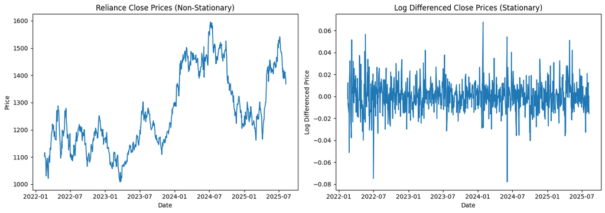

```python
plt.figure(figsize=(14, 5))

plt.subplot(1, 2, 1)
plt.plot(df_features['Date'], df_features['Close'])
plt.title('Reliance Close Prices (Non-Stationary)')
plt.xlabel('Date')
plt.ylabel('Price')

plt.subplot(1, 2, 2)
plt.plot(df_features['Date'], df_features['log_close_diff'])
plt.title('Log Differenced Close Prices (Stationary)')
plt.xlabel('Date')
plt.ylabel('Log Differenced Price')

plt.tight_layout()
plt.show()
```

The p-value is well below 0.05, so we reject the null hypothesis of non-stationarity. The log-differenced Reliance closing prices are now stationary, making the series suitable for:

ARIMA/SARIMA time series forecasting.

# Why Lag Returns Are Important in Time Series Analysis

Capturing Autocorrelation (Momentum/Reversal Patterns) Financial returns often exhibit:

**Short-term autocorrelation (momentum): Positive/negative returns may persist briefly.

**Mean reversion: Negative autocorrelation over certain lags.

Using lag returns helps your model capture these patterns for better forecasting.

```python
for lag in range(1,6):
    df_features[f'reliance_lag{lag}'] = df_features['reliance_returns'].shift(lag)

df_features.dropna(inplace=True)
```

```python
print(df_features[['reliance_returns', 'reliance_lag1', 'reliance_lag2', 'reliance_lag3', 'reliance_lag4', 'reliance_lag5']].head(10))
```

```
Price  reliance_returns reliance_lag1 reliance_lag2 reliance_lag3  \
Ticker
35            -0.049831     -0.006258     -0.014602     -0.007817
36             0.012501     -0.049831     -0.006258     -0.014602
37             0.033100      0.012501     -0.049831     -0.006258
38             0.016529      0.033100      0.012501     -0.049831
39            -0.008443      0.016529      0.033100      0.012501
40            -0.022180     -0.008443      0.016529      0.033100
41            -0.036980     -0.022180     -0.008443      0.016529
42            -0.001808     -0.036980     -0.022180     -0.008443
43             0.053053     -0.001808     -0.036980     -0.022180
44             0.016206      0.053053     -0.001808     -0.036980

Price  reliance_lag4 reliance_lag5
Ticker
35          0.012661     -0.002068
36         -0.007817      0.012661
37         -0.014602     -0.007817
38         -0.006258     -0.014602
39         -0.049831     -0.006258
40          0.012501     -0.049831
41          0.033100      0.012501
42          0.016529      0.033100
43         -0.008443      0.016529
44         -0.022180     -0.008443
```

The Relative Strength Index (RSI) is a momentum indicator that measures the magnitude of recent price changes to evaluate overbought or oversold conditions in the price of a stock

Moving Average Convergence Divergence, is a technical indicator used in trading to identify changes in the strength, direction, momentum, and duration of a trend in an asset's price.

```python
def compute_rsi(series, period=14):
    delta = series.diff()
    gain = delta.where(delta > 0, 0)
    loss = -delta.where(delta < 0, 0)

    avg_gain = gain.rolling(window=period).mean()
    avg_loss = loss.rolling(window=period).mean()

    rs = avg_gain / avg_loss
    rsi = 100 - (100 / (1 + rs))
    return rsi

# Calculate RSI on Reliance close price
df_features['RSI_14'] = compute_rsi(df_features['Close'], period=14)

# --- MACD Calculation ---
ema_12 = df_features['Close'].ewm(span=12, adjust=False).mean()
ema_26 = df_features['Close'].ewm(span=26, adjust=False).mean()

df_features['MACD'] = ema_12 - ema_26
df_features['MACD_Signal'] = df_features['MACD'].ewm(span=9, adjust=False).mean()
df_features['MACD_Hist'] = df_features['MACD'] - df_features['MACD_Signal']

# Drop NaN for clean analysis
df_features.dropna(inplace=True)

# Quick check
print(df_features[['Close', 'RSI_14', 'MACD', 'MACD_Signal', 'MACD_Hist']].head(10))
```

```
Price         Close     RSI_14       MACD MACD_Signal  MACD_Hist
Ticker  RELIANCE.NS
48      1097.920654  62.626160  15.316279   11.162456   4.153823
49      1133.713379  67.043824  18.853874   12.700740   6.153134
50      1127.180542  64.134322  20.889497   14.338491   6.551006
51      1156.303589  63.467268  24.569508   16.384695   8.184813
52      1159.980835  61.601855  27.466054   18.600967   8.865087
53      1178.002808  66.019016  30.860075   21.052788   9.807286
54      1185.860352  72.914510  33.794338   23.601098  10.193240
55      1197.783691  86.082210  36.659292   26.212737  10.446555
56      1198.057739  86.760324  38.508005   28.671791   9.836215
57      1221.081909  84.789901  41.354276   31.208288  10.145988
```

```python
import plotly.io as pio
# RSI Plot
fig_rsi = go.Figure()

fig_rsi.add_trace(go.Scatter(
    x=df_features['Date'],
    y=df_features['RSI_14'],
    mode='lines',
    name='RSI 14',
    line=dict(color='orange')
))

# Overbought and oversold lines
fig_rsi.add_hline(y=70, line_dash="dash", line_color="red", annotation_text="Overbought (70)")
fig_rsi.add_hline(y=30, line_dash="dash", line_color="green", annotation_text="Oversold (30)")

fig_rsi.update_layout(
    title='Reliance RSI (14-Day)',
    xaxis_title='Date',
    yaxis_title='RSI',
    height=500
)

fig_rsi.show()

# MACD Plot
fig_macd = go.Figure()

fig_macd.add_trace(go.Scatter(
    x=df_features['Date'],
    y=df_features['MACD'],
    mode='lines',
    name='MACD',
    line=dict(color='blue')
))

fig_macd.add_trace(go.Scatter(
    x=df_features['Date'],
    y=df_features['MACD_Signal'],
    mode='lines',
    name='Signal Line',
    line=dict(color='red')
))

# MACD Histogram as Bar Chart
fig_macd.add_trace(go.Bar(
    x=df_features['Date'],
    y=df_features['MACD_Hist'],
    name='MACD Histogram',
    marker_color='grey',
    opacity=0.4
))

fig_macd.update_layout(
    title='Reliance MACD',
    xaxis_title='Date',
    yaxis_title='MACD Value',
    barmode='overlay',
    height=500,
    legend = dict(
        orientation = 'h',
        yanchor = 'bottom',
        y = 1.02,
        xanchor = 'center',
        x =0.5
    )
)

fig_macd.show()
```

[interactive chart not shown]

# Value at Risk (VaR)

To quantify the potential downside risk of investing in Reliance using VaR under your systematic deep analysis.

```python
returns = df_features['reliance_returns'].dropna()

confidence_level = 0.95

hist_var = np.percentile(returns, (1 - confidence_level) * 100)

mean_return = returns.mean()
std_return = returns.std()
from scipy.stats import norm

parametric_var = norm.ppf(1 - confidence_level, mean_return, std_return)

print(f"Historical VaR at 95% confidence: {hist_var*100:.2f}%")
print(f"Parametric VaR at 95% confidence: {parametric_var*100:.2f}%")
```

```
Historical VaR at 95% confidence: -1.99%
Parametric VaR at 95% confidence: -2.26%
```

Historical VaR (95%): -1.99%

@ Reliance is not expected to lose more than 1.99% in a day, 95% of the time under historical conditions.

```python
df_features.columns
```

```
MultiIndex([(            'Date',            ''),
            (            'Open', 'RELIANCE.NS'),
            (           'Close', 'RELIANCE.NS'),
            (            'High', 'RELIANCE.NS'),
            (             'Low', 'RELIANCE.NS'),
            (          'Volume', 'RELIANCE.NS'),
            (     'nifty_Close',       '^NSEI'),
            (       'oil_Close',        'BZ=F'),
            (    'usdinr_Close',       'INR=X'),
            ('reliance_returns',            ''),
            (   'nifty_returns',            ''),
            (     'oil_returns',            ''),
            (  'usdinr_returns',            ''),
            (           'MA_10',            ''),
            (           'MA_30',            ''),
            (          'EMA_10',            ''),
            (          'EMA_30',            ''),
            (      'Volatility',            ''),
            (       'log_close',            ''),
            (  'log_close_diff',            ''),
            (   'reliance_lag1',            ''),
            (   'reliance_lag2',            ''),
            (   'reliance_lag3',            ''),
            (   'reliance_lag4',            ''),
            (   'reliance_lag5',            ''),
            (          'RSI_14',            ''),
            (            'MACD',            ''),
            (     'MACD_Signal',            ''),
            (       'MACD_Hist',            '')],
           names=['Price', 'Ticker'])
```

# **Modelling**

```
Naïve Prediction RMSE: 18.10
Naïve Prediction MAE: 13.89
```

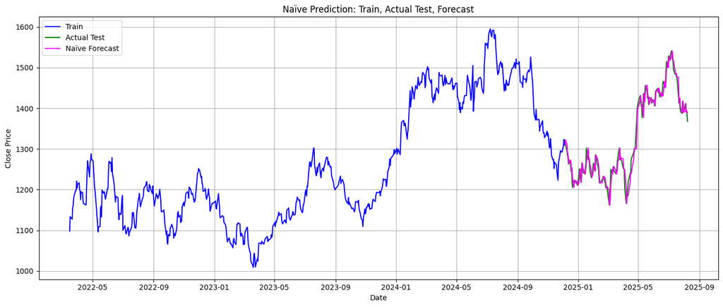

```python
series = df_features[['Date', 'Close']].copy()
series['Naive_Pred'] = series['Close'].shift(1)

# Split train-test
train_size = int(len(series) * 0.8)
train = series.iloc[:train_size]
test = series.iloc[train_size:]

# Evaluation only on the test set (drop first NaN in Naïve)
test_eval = test.dropna()

# Calculate RMSE and MAE
rmse_naive = np.sqrt(mean_squared_error(test_eval['Close'], test_eval['Naive_Pred']))
mae_naive = mean_absolute_error(test_eval['Close'], test_eval['Naive_Pred'])

print(f"Naïve Prediction RMSE: {rmse_naive:.2f}")
print(f"Naïve Prediction MAE: {mae_naive:.2f}")

# Plot
plt.figure(figsize=(14,6))

# Train
plt.plot(train['Date'], train['Close'], label='Train', color='blue')

# Actual Test
plt.plot(test['Date'], test['Close'], label='Actual Test', color='green')

# Naïve Forecast
plt.plot(test['Date'], test['Naive_Pred'], label='Naïve Forecast', color='magenta')

plt.title("Naïve Prediction: Train, Actual Test, Forecast")
plt.xlabel('Date')
plt.ylabel('Close Price')
plt.legend()
plt.grid(True)
plt.tight_layout()
plt.show()
```

```
ARIMA RMSE: 106.76
ARIMA MAE: 93.61
```

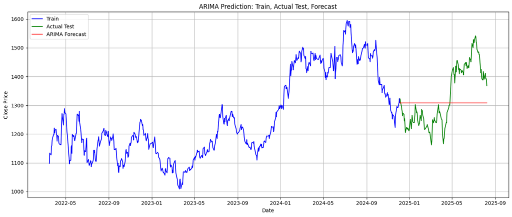

```python
# Assuming df_features['Date'] is datetime
series = df_features[['Date', 'Close']].copy()
series.set_index('Date', inplace=True)

# Split train/test
train_size = int(len(series) * 0.8)
train, test = series.iloc[:train_size], series.iloc[train_size:]

# Fit ARIMA model (p,d,q) → choose params using AIC/BIC or trial
arima_model = ARIMA(train['Close'], order=(5,1,0))
arima_fit = arima_model.fit()

# Forecast same length as test
arima_forecast = arima_fit.forecast(steps=len(test))

# Evaluation
rmse_arima = np.sqrt(mean_squared_error(test['Close'], arima_forecast))
mae_arima = mean_absolute_error(test['Close'], arima_forecast)
print(f"ARIMA RMSE: {rmse_arima:.2f}")
print(f"ARIMA MAE: {mae_arima:.2f}")

# Plot
plt.figure(figsize=(14,6))
plt.plot(train.index, train['Close'], label='Train', color='blue')
plt.plot(test.index, test['Close'], label='Actual Test', color='green')
plt.plot(test.index, arima_forecast, label='ARIMA Forecast', color='red')
plt.title("ARIMA Prediction: Train, Actual Test, Forecast")
plt.xlabel('Date')
plt.ylabel('Close Price')
plt.legend()
plt.grid(True)
plt.tight_layout()
plt.show()
```

```
SARIMA RMSE: 92.88
SARIMA MAE: 84.49
```

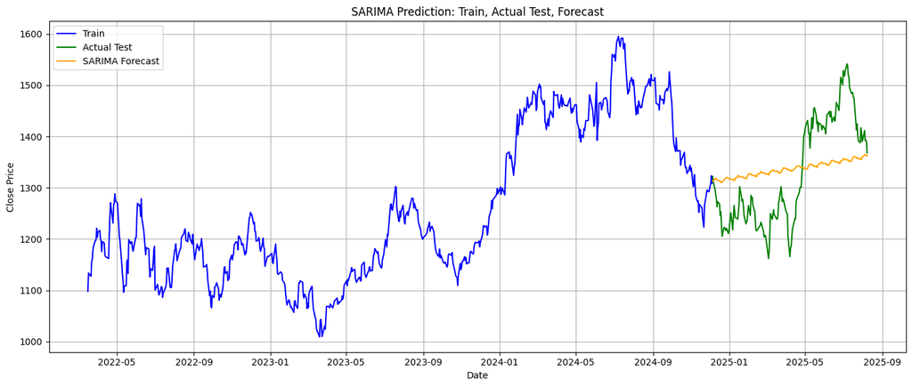

```python
from statsmodels.tsa.statespace.sarimax import SARIMAX

# Fit SARIMA model (p,d,q)(P,D,Q,s) → adjust params based on seasonality
sarima_model = SARIMAX(train['Close'], order=(5,1,0), seasonal_order=(1,1,1,12))
sarima_fit = sarima_model.fit(disp=False)

# Forecast
sarima_forecast = sarima_fit.forecast(steps=len(test))

# Evaluation
rmse_sarima = np.sqrt(mean_squared_error(test['Close'], sarima_forecast))
mae_sarima = mean_absolute_error(test['Close'], sarima_forecast)
print(f"SARIMA RMSE: {rmse_sarima:.2f}")
print(f"SARIMA MAE: {mae_sarima:.2f}")

# Plot
plt.figure(figsize=(14,6))
plt.plot(train.index, train['Close'], label='Train', color='blue')
plt.plot(test.index, test['Close'], label='Actual Test', color='green')
plt.plot(test.index, sarima_forecast, label='SARIMA Forecast', color='orange')
plt.title("SARIMA Prediction: Train, Actual Test, Forecast")
plt.xlabel('Date')
plt.ylabel('Close Price')
plt.legend()
plt.grid(True)
plt.tight_layout()
plt.show()
```